# STAT 6302 - Project

- Show All Code
- Hide All Code
- View Source

Author

Baldwin, Jamie

**SHOW ME THE CODE!**

```r
autism <- read.csv("C:\\Users\\jasmi\\OneDrive - Southern Methodist University\\6302\\Project\\autism+screening+adult\\autism.csv")
head(autism)
```

```
  A1_Score A2_Score A3_Score A4_Score A5_Score A6_Score A7_Score A8_Score
1        1        1        1        1        0        0        1        1
2        1        1        0        1        0        0        0        1
3        1        1        0        1        1        0        1        1
4        1        1        0        1        0        0        1        1
5        1        0        0        0        0        0        0        1
6        1        1        1        1        1        0        1        1
  A9_Score A10_Score age gender      ethnicity jundice austim contry_of_res
1        0         0  26      f White-European      no     no United States
2        0         1  24      m         Latino      no    yes        Brazil
3        1         1  27      m         Latino     yes    yes         Spain
4        0         1  35      f White-European      no    yes United States
5        0         0  40      f           <NA>      no     no         Egypt
6        1         1  36      m         Others     yes     no United States
  used_app_before result    age_desc relation Class.ASD
1              no      6 18 and more     Self        NO
2              no      5 18 and more     Self        NO
3              no      8 18 and more   Parent       YES
4              no      6 18 and more     Self        NO
5              no      2 18 and more     <NA>        NO
6              no      9 18 and more     Self       YES
```

## Exploratory Data Analysis

### Variable Types & Distributions

**SHOW ME THE CODE!**

```r
### WE WANT TO CATCH ANY MISSING VALUES AND CORRECTLY CHANGE THEM TO NAs

# Combine "others" into "Others" in the ethnicity variable
autism$ethnicity <- ifelse(autism$ethnicity == "others", "Others", autism$ethnicity)


# Replace "" and "?" with NA across all character or factor columns
autism[] <- lapply(autism, function(x) {
  if (is.character(x) || is.factor(x)) {
    x <- as.character(x)
    x[x == "" | x == "?"] <- NA
    return(as.factor(x))  # Reconvert to factor if desired
  } else {
    return(x)
  }
})

# Also convert numeric "NA-like" values (if stored as strings) to actual NA
autism[] <- lapply(autism, function(x) {
  if (is.character(x)) {
    x[x %in% c("NA", "na", "NaN", "null")] <- NA
    return(as.factor(x))
  } else {
    return(x)
  }
})

### WANT TO RENAME SOME MISSPELLED VARIABLE NAMES

# Rename variables in the dataset
names(autism)[names(autism) == "austim"] <- "autism"
names(autism)[names(autism) == "jundice"] <- "jaundice"
names(autism)[names(autism) == "contry_of_res"] <- "country_of_res"



lapply(autism, unique)
```

```
$A1_Score
[1] 1 0

$A2_Score
[1] 1 0

$A3_Score
[1] 1 0

$A4_Score
[1] 1 0

$A5_Score
[1] 0 1

$A6_Score
[1] 0 1

$A7_Score
[1] 1 0

$A8_Score
[1] 1 0

$A9_Score
[1] 0 1

$A10_Score
[1] 0 1

$age
 [1]  26  24  27  35  40  36  17  64  29  33  18  31  30  34  38  42  43  48  37
[20]  55  50  53  20  28  21 383  47  32  44  NA  19  58  45  22  39  25  23  54
[39]  60  41  46  56  61  59  52  49  51

$gender
[1] f m
Levels: f m

$ethnicity
```

[output cut: 43 more lines]

```
$result
 [1]  6  5  8  2  9 10  4  3  0  1  7

$age_desc
[1] 18 and more
Levels: 18 and more

$relation
[1] Self                     Parent                   <NA>
[4] Health care professional Relative                 Others
Levels: Health care professional Others Parent Relative Self

$Class.ASD
[1] NO  YES
Levels: NO YES
```

**SHOW ME THE CODE!**

```r
# Load libraries
library(tidyverse)
```

**SHOW ME THE CODE!**

```r
library(janitor)
```

**SHOW ME THE CODE!**

```r
library(ggplot2)
library(patchwork)  #For multi-plot layout
```

**SHOW ME THE CODE!**

```r
#Clean names, just in case
autism <- clean_names(autism)

#Quick structure view
glimpse(autism)
```

```
Rows: 704
Columns: 21
$ a1_score        <int> 1, 1, 1, 1, 1, 1, 0, 1, 1, 1, 1, 0, 0, 1, 1, 1, 1, 0, …
$ a2_score        <int> 1, 1, 1, 1, 0, 1, 1, 1, 1, 1, 1, 1, 1, 0, 0, 1, 0, 0, …
$ a3_score        <int> 1, 0, 0, 0, 0, 1, 0, 1, 0, 1, 1, 0, 1, 0, 0, 0, 0, 0, …
$ a4_score        <int> 1, 1, 1, 1, 0, 1, 0, 1, 0, 1, 1, 1, 1, 0, 0, 1, 0, 0, …
$ a5_score        <int> 0, 0, 1, 0, 0, 1, 0, 0, 1, 0, 1, 1, 1, 0, 0, 1, 0, 0, …
$ a6_score        <int> 0, 0, 0, 0, 0, 0, 0, 0, 0, 1, 1, 1, 1, 0, 0, 0, 0, 0, …
$ a7_score        <int> 1, 0, 1, 1, 0, 1, 0, 0, 0, 1, 1, 1, 0, 1, 1, 0, 1, 0, …
$ a8_score        <int> 1, 1, 1, 1, 1, 1, 1, 0, 1, 1, 1, 0, 0, 1, 1, 1, 1, 1, …
$ a9_score        <int> 0, 0, 1, 0, 0, 1, 0, 1, 1, 1, 1, 0, 1, 0, 0, 0, 1, 0, …
$ a10_score       <int> 0, 1, 1, 1, 0, 1, 0, 0, 1, 0, 1, 1, 0, 1, 1, 1, 1, 1, …
$ age             <int> 26, 24, 27, 35, 40, 36, 17, 64, 29, 17, 33, 18, 17, 17…
$ gender          <fct> f, m, m, f, f, m, f, m, m, m, m, f, f, m, f, m, m, m, …
$ ethnicity       <fct> White-European, Latino, Latino, White-European, NA, Ot…
$ jaundice        <fct> no, no, yes, no, no, yes, no, no, no, yes, no, no, no,…
$ autism          <fct> no, yes, yes, yes, no, no, no, no, no, yes, no, no, no…
$ country_of_res  <fct> United States, Brazil, Spain, United States, Egypt, Un…
$ used_app_before <fct> no, no, no, no, no, no, no, no, no, no, no, no, no, no…
$ result          <int> 6, 5, 8, 6, 2, 9, 2, 5, 6, 8, 10, 6, 6, 4, 4, 6, 5, 2,…
$ age_desc        <fct> 18 and more, 18 and more, 18 and more, 18 and more, 18…
$ relation        <fct> Self, Self, Parent, Self, NA, Self, Self, Parent, Self…
$ class_asd       <fct> NO, NO, YES, NO, NO, YES, NO, NO, NO, YES, YES, NO, NO…
```

**SHOW ME THE CODE!**

```r
#Create histograms for A1–A10 Scores using a loop
score_vars <- paste0("a", 1:10, "_score")

score_plots <- lapply(score_vars, function(var) {
  ggplot(autism, aes_string(x = var)) +
    geom_histogram(binwidth = 1, fill = "lightsteelblue", color = "black") +
    labs(title = paste0("Distribution of ", toupper(var)), x = var, y = "Count")
})
```

**SHOW ME THE CODE!**

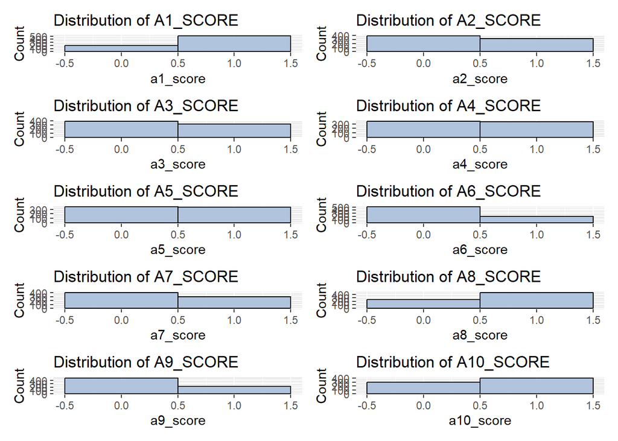

```r
#Arrange a few sample plots using patchwork
(score_plots[[1]] | score_plots[[2]]) /
(score_plots[[3]] | score_plots[[4]]) /
(score_plots[[5]] | score_plots[[6]])/
(score_plots[[7]] | score_plots[[8]]) /
(score_plots[[9]] | score_plots[[10]])
```

**SHOW ME THE CODE!**

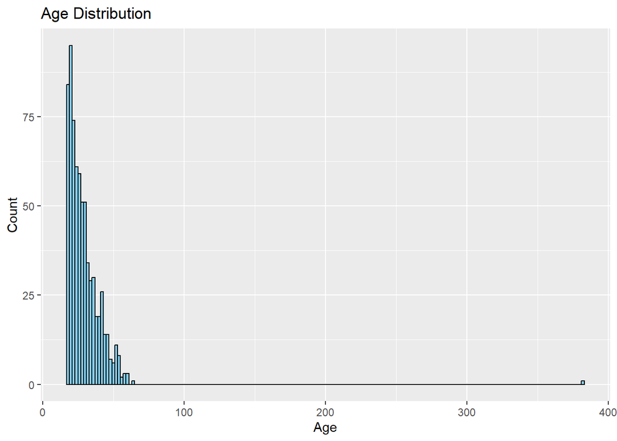

```r
#Histogram: Age
ggplot(autism, aes(x = age)) +
  geom_histogram(binwidth = 2, fill = "skyblue", color = "black") +
  labs(title = "Age Distribution", x = "Age", y = "Count")
```

**SHOW ME THE CODE!**

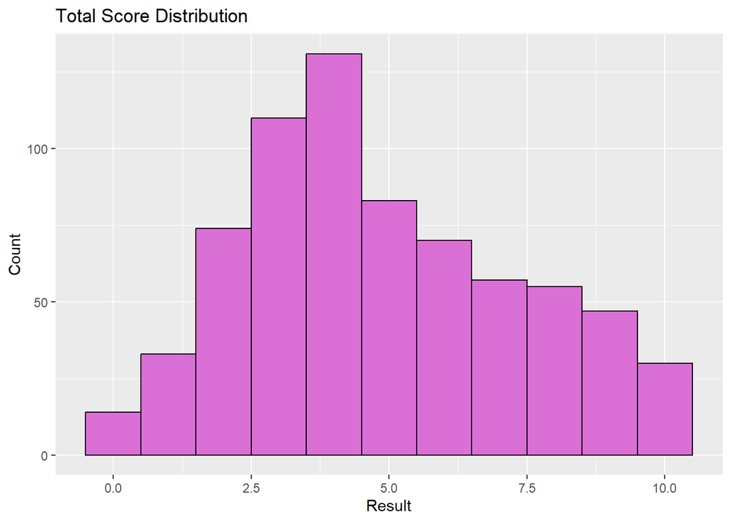

```r
#Histogram: Result Score
ggplot(autism, aes(x = result)) +
  geom_histogram(binwidth = 1, fill = "orchid", color = "black") +
  labs(title = "Total Score Distribution", x = "Result", y = "Count")
```

**SHOW ME THE CODE!**

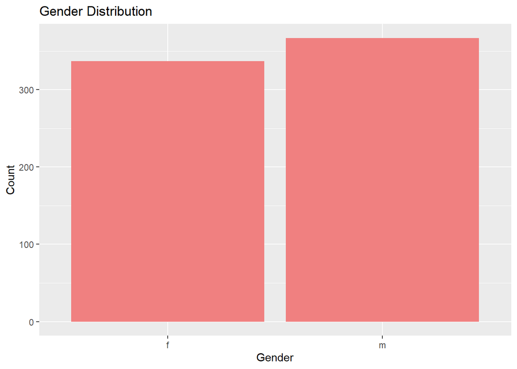

```r
#Bar plot: Gender
ggplot(autism, aes(x = gender)) +
  geom_bar(fill = "lightcoral") +
  labs(title = "Gender Distribution", x = "Gender", y = "Count")
```

**SHOW ME THE CODE!**

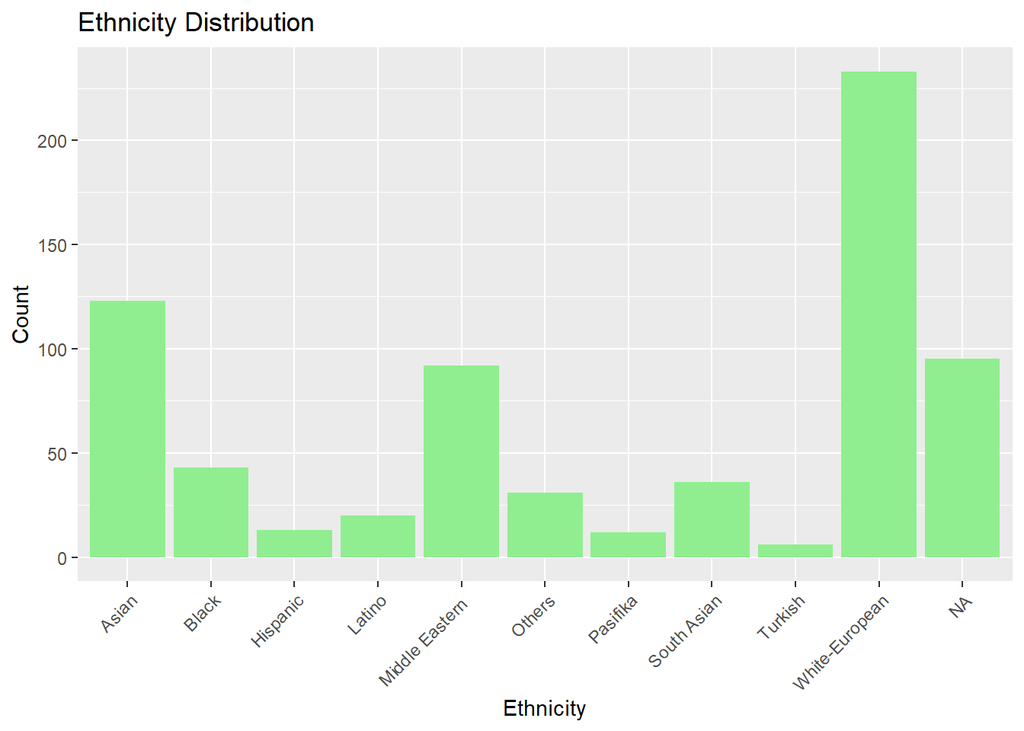

```r
#Bar plot: Ethnicity
ggplot(autism, aes(x = ethnicity)) +
  geom_bar(fill = "lightgreen") +
  labs(title = "Ethnicity Distribution", x = "Ethnicity", y = "Count") +
  theme(axis.text.x = element_text(angle = 45, hjust = 1))
```

**SHOW ME THE CODE!**

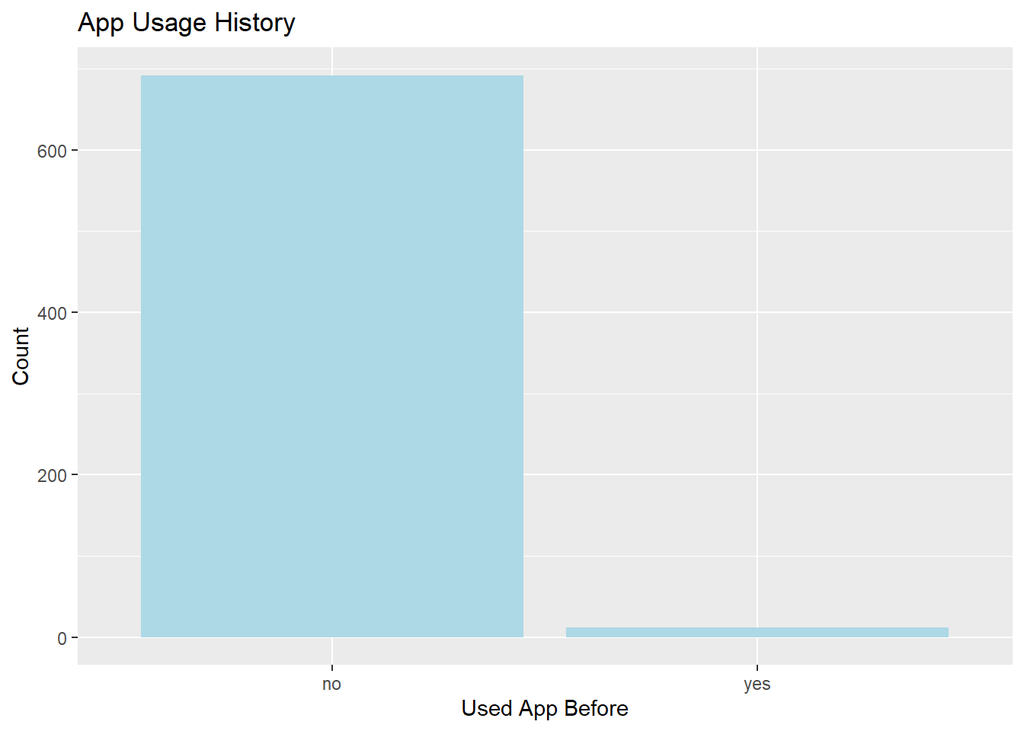

```r
#Bar plot: Used App Before
ggplot(autism, aes(x = used_app_before)) +
  geom_bar(fill = "lightblue") +
  labs(title = "App Usage History", x = "Used App Before", y = "Count")
```

**SHOW ME THE CODE!**

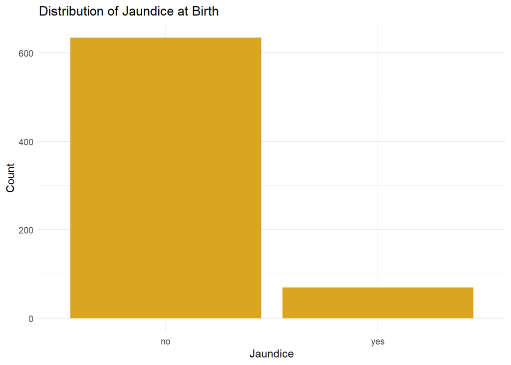

```r
ggplot(autism, aes(x = jaundice)) +
  geom_bar(fill = "goldenrod") +
  labs(title = "Distribution of Jaundice at Birth", x = "Jaundice", y = "Count") +
  theme_minimal()
```

**SHOW ME THE CODE!**

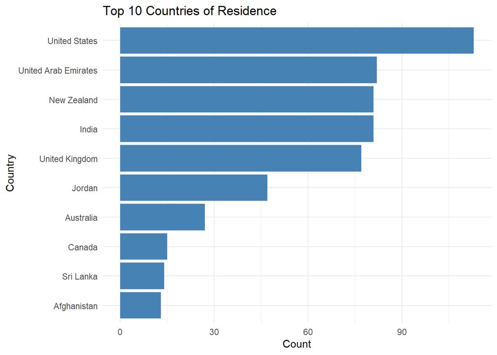

```r
library(forcats)

autism %>%
  count(country_of_res, sort = TRUE) %>%
  top_n(10, n) %>%
  ggplot(aes(x = fct_reorder(country_of_res, n), y = n)) +
  geom_col(fill = "steelblue") +
  coord_flip() +
  labs(title = "Top 10 Countries of Residence", x = "Country", y = "Count") +
  theme_minimal()
```

**SHOW ME THE CODE!**

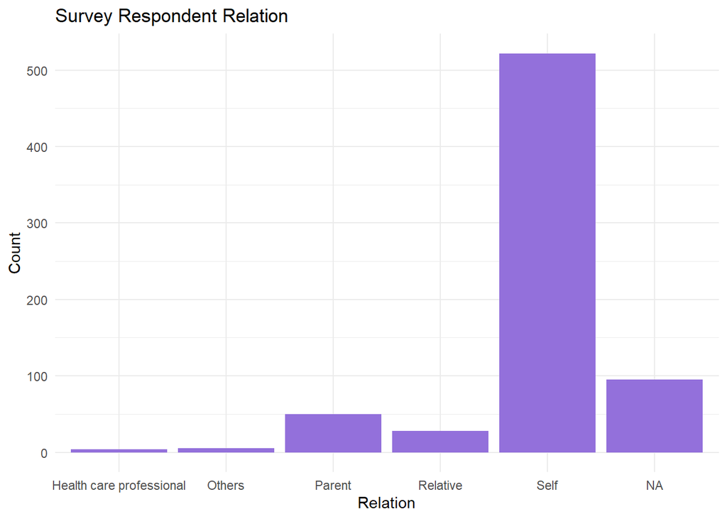

```r
ggplot(autism, aes(x = relation)) +
  geom_bar(fill = "mediumpurple") +
  labs(title = "Survey Respondent Relation", x = "Relation", y = "Count") +
  theme_minimal()
```

**FROM BOTH THE UNIQUE VALUES CODE AND AGE DISTRIBUTION GRAPH ABOVE WE CAN SEE AN INPUTING ERROR IN THE DATA HAS OCCURED WITH AN AGE VALUE OF 383, I WOULD SAY IT IS SAFE TO ASSUME THE CORRECT AGE WAS MEANT TO BE 38. I WILL MAKE THE ASSUMPTION IT WAS MEANT TO BE 38 AS THE REST OF THE AGES RANGE FROM 17 TO 64, AND RECREATE THAT GRAPH.**

**SHOW ME THE CODE!**

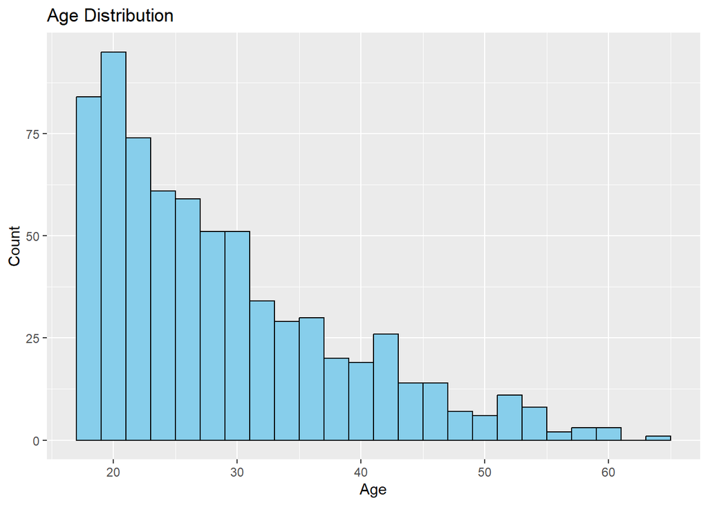

```r
#Fixing the typo in age
autism$age[autism$age == 383] <- 38

#Histogram: Age
ggplot(autism, aes(x = age)) +
  geom_histogram(binwidth = 2, fill = "skyblue", color = "black") +
  labs(title = "Age Distribution", x = "Age", y = "Count")
```

### Drop Variables

Since the variable age description (age_desc) only has one level “18 and more” we can remove it completely as it wont add anything to the model.

**SHOW ME THE CODE!**

```r
# Function to show unique values and their counts
value_counts <- function(var) {
  tbl <- table(var, useNA = "ifany")
  print(tbl)
  cat("\nTotal unique values (including NA):", length(tbl), "\n")
}

# Example usage:
value_counts(autism$age_desc)
```

```
var
18 and more
        704

Total unique values (including NA): 1
```

**SHOW ME THE CODE!**

```r
value_counts(autism$relation)
```

```
var
Health care professional                   Others                   Parent
                       4                        5                       50
                Relative                     Self                     <NA>
                      28                      522                       95

Total unique values (including NA): 6
```

**SHOW ME THE CODE!**

```r
value_counts(autism$used_app_before)
```

```
var
 no yes
692  12

Total unique values (including NA): 2
```

**SHOW ME THE CODE!**

```r
value_counts(autism$jaundice)
```

```
var
 no yes
635  69

Total unique values (including NA): 2
```

**SHOW ME THE CODE!**

```r
#Drop the variable 'age_desc'
autism <- autism[, !names(autism) %in% "age_desc"]
autism <- autism[, !names(autism) %in% "used_app_before"]
```

### Missing Data

**SHOW ME THE CODE!**

```r
#Count of missing values per variable
colSums(is.na(autism))
```

```
      a1_score       a2_score       a3_score       a4_score       a5_score
             0              0              0              0              0
      a6_score       a7_score       a8_score       a9_score      a10_score
             0              0              0              0              0
           age         gender      ethnicity       jaundice         autism
             2              0             95              0              0
country_of_res         result       relation      class_asd
             0              0             95              0
```

**SHOW ME THE CODE!**

```r
#Impute age with mean
autism$age[is.na(autism$age)] <- mean(autism$age, na.rm = TRUE)

#Function to compute mode (most frequent value)
get_mode <- function(x) {
  ux <- na.omit(unique(x))
  ux[which.max(tabulate(match(x, ux)))]
}

#Impute ethnicity with mode
autism$ethnicity[is.na(autism$ethnicity)] <- get_mode(autism$ethnicity)

#Impute relation with mode
autism$relation[is.na(autism$relation)] <- get_mode(autism$relation)
```

### Encode

BESURE TO INCLUDE DUMMY INCODING IN RECIPE

### Split into Predictors and Outcome

THIS WILL BE DONE IN THE MODEL RECIPE

### Outcome Variable Balance

**SHOW ME THE CODE!**

```r
#Convert outcome variable to factor
autism$autism <- as.factor(autism$autism)

#Frequency table
table(autism$autism)
```

```
 no yes
613  91
```

**SHOW ME THE CODE!**

```r
#Proportion table
prop.table(table(autism$autism))
```

```
       no       yes
0.8707386 0.1292614
```

**SHOW ME THE CODE!**

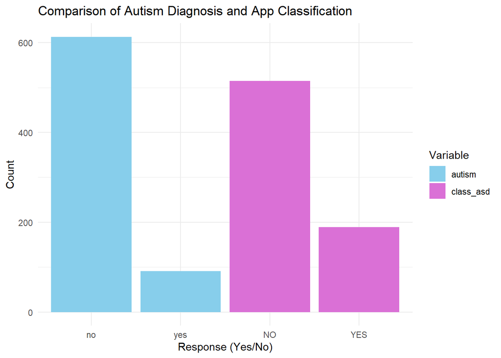

```r
library(ggplot2)
library(dplyr)

# Bar plot: Count comparison
autism %>%
  select(autism, class_asd) %>%
  pivot_longer(cols = everything(), names_to = "Variable", values_to = "Response") %>%
  ggplot(aes(x = Response, fill = Variable)) +
  geom_bar(position = "dodge") +
  labs(title = "Comparison of Autism Diagnosis and App Classification",
       x = "Response (Yes/No)", y = "Count") +
  scale_fill_manual(values = c("autism" = "skyblue", "class_asd" = "orchid")) +
  theme_minimal()
```

### Up-Sampling

CAN DO THIS IN RECIPE

### Correlations & Associations

**SHOW ME THE CODE!**

```r
### numeric variables ###
numeric_vars <- autism %>% select_if(is.numeric)

#Correlation matrix
cor_matrix <- cor(numeric_vars, use = "pairwise.complete.obs")

#Plot
library(corrplot)
```

**SHOW ME THE CODE!**

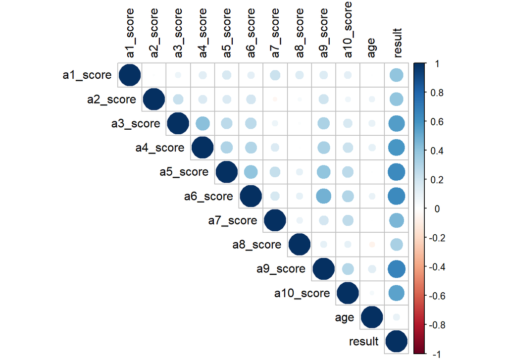

```r
corrplot::corrplot(cor_matrix, method = "circle", type = "upper", tl.col = "black")
```

**SHOW ME THE CODE!**

```r
### Categorical Variables ###

# Load required libraries
library(ggplot2)
library(dplyr)
library(patchwork)  # for arranging plots

### Categorical Variables - Chi-square Tests ###
table_gender <- table(autism$gender, autism$autism)
chisq.test(table_gender)
```

```
    Pearson's Chi-squared test with Yates' continuity correction

data:  table_gender
X-squared = 4.9957, df = 1, p-value = 0.02541
```

**SHOW ME THE CODE!**

```r
table_ethnicity <- table(autism$ethnicity, autism$autism)
chisq.test(table_ethnicity)
```

```
    Pearson's Chi-squared test

data:  table_ethnicity
X-squared = 30.922, df = 9, p-value = 0.0003053
```

**SHOW ME THE CODE!**

```r
table_relation <- table(autism$relation, autism$autism)
chisq.test(table_relation)
```

```
    Pearson's Chi-squared test

data:  table_relation
X-squared = 11.502, df = 4, p-value = 0.02147
```

**SHOW ME THE CODE!**

```r
table_jaundice <- table(autism$jaundice, autism$autism)
chisq.test(table_jaundice)
```

```
    Pearson's Chi-squared test with Yates' continuity correction

data:  table_jaundice
X-squared = 15.982, df = 1, p-value = 6.393e-05
```

**SHOW ME THE CODE!**

```r
table_cor <- table(autism$country_of_res, autism$autism)
chisq.test(table_cor)
```

```
    Pearson's Chi-squared test

data:  table_cor
X-squared = 115.05, df = 66, p-value = 0.0001769
```

**SHOW ME THE CODE!**

```r
table_class <- table(autism$class_asd, autism$autism)
chisq.test(table_class)
```

```
    Pearson's Chi-squared test with Yates' continuity correction

data:  table_class
X-squared = 20.982, df = 1, p-value = 4.636e-06
```

**SHOW ME THE CODE!**

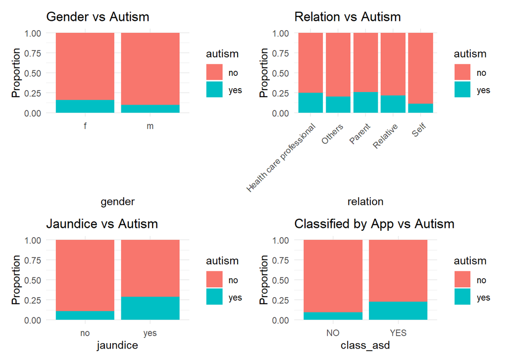

```r
### Stacked Bar Plots ###
p1 <- ggplot(autism, aes(x = gender, fill = autism)) +
  geom_bar(position = "fill") +
  ylab("Proportion") +
  ggtitle("Gender vs Autism") +
  theme_minimal()

p2 <- ggplot(autism, aes(x = ethnicity, fill = autism)) +
  geom_bar(position = "fill") +
  ylab("Proportion") +
  ggtitle("Ethnicity vs Autism") +
  theme_minimal() +
  theme(axis.text.x = element_text(angle = 45, hjust = 1))

p3 <- ggplot(autism, aes(x = relation, fill = autism)) +
  geom_bar(position = "fill") +
  ylab("Proportion") +
  ggtitle("Relation vs Autism") +
  theme_minimal() +
  theme(axis.text.x = element_text(angle = 45, hjust = 1))

p4 <- ggplot(autism, aes(x = jaundice, fill = autism)) +
  geom_bar(position = "fill") +
  ylab("Proportion") +
  ggtitle("Jaundice vs Autism") +
  theme_minimal()

library(forcats)

# Create a new variable with only the top 10 countries
autism <- autism %>%
  mutate(top_country = fct_lump(country_of_res, n = 10))

# Updated stacked bar plot
p5 <- ggplot(autism, aes(x = top_country, fill = autism)) +
  geom_bar(position = "fill") +
  ylab("Proportion") +
  ggtitle("Top 10 Countries vs Autism") +
  theme_minimal() +
  theme(axis.text.x = element_text(angle = 45, hjust = 1))


p6 <- ggplot(autism, aes(x = class_asd, fill = autism)) +
  geom_bar(position = "fill") +
  ylab("Proportion") +
  ggtitle("Classified by App vs Autism") +
  theme_minimal()

### Arrange Plots into Grid ###
(p1 | p3)/(p4 | p6)
```

**SHOW ME THE CODE!**

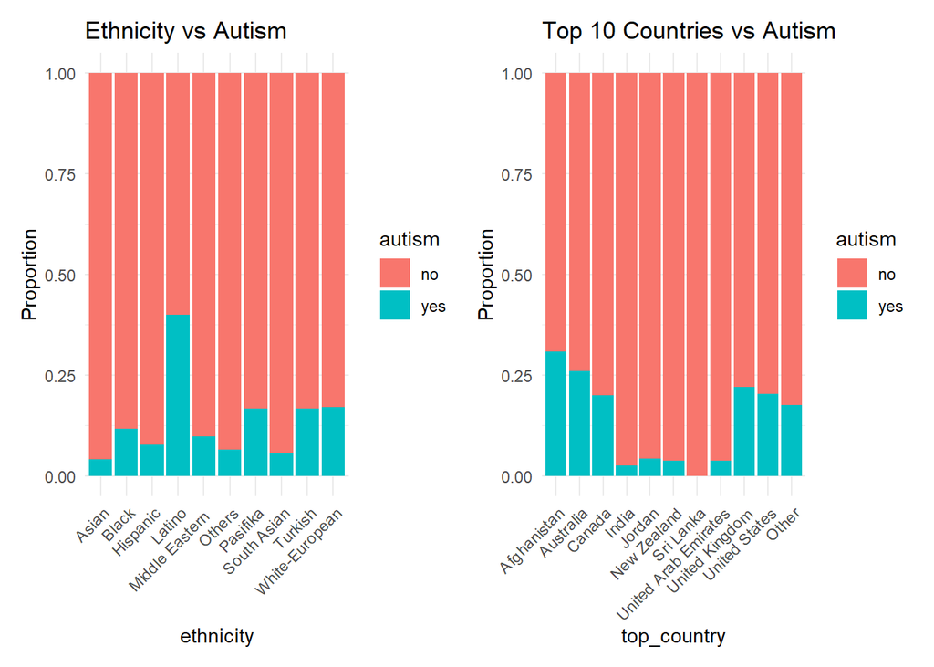

```r
(p2 | p5)
```

### Survey Score Patterns

**SHOW ME THE CODE!**

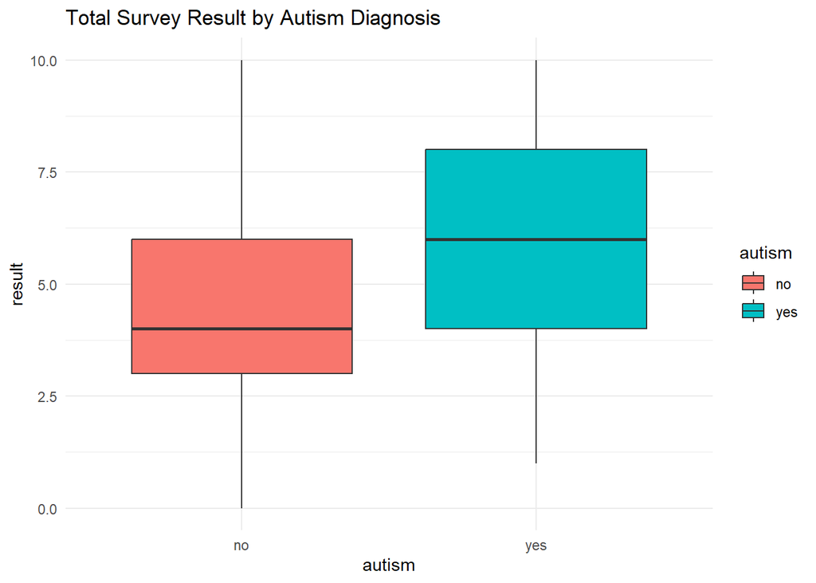

```r
#Boxplot of result by autism
ggplot(autism, aes(x = autism, y = result, fill = autism)) +
  geom_boxplot() +
  theme_minimal() +
  ggtitle("Total Survey Result by Autism Diagnosis")
```

**SHOW ME THE CODE!**

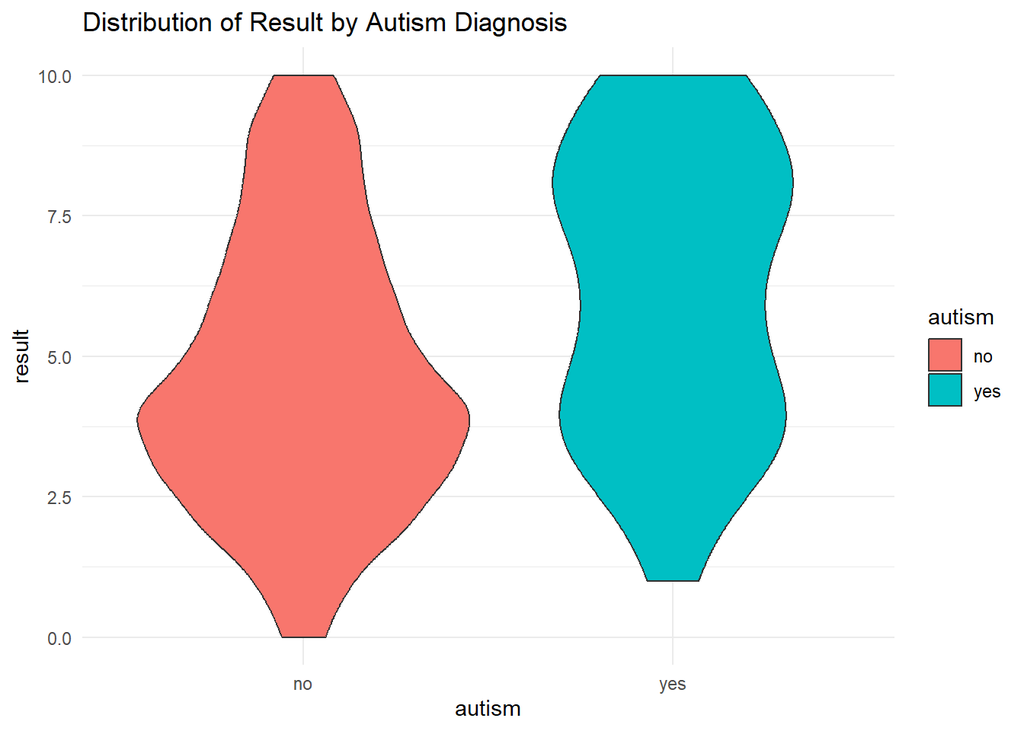

```r
#Or use violin plot
ggplot(autism, aes(x = autism, y = result, fill = autism)) +
  geom_violin() +
  theme_minimal() +
  ggtitle("Distribution of Result by Autism Diagnosis")
```

These plots pretty much confirm what we know about scoring for any autism screening survey that it’s not perfect and is on more of a sliding scale than a defined one. So for the lack of additional context this section will not be included in the report.

### Interaction Exploration

**SHOW ME THE CODE!**

```r
# Load required library
library(dplyr)

# Set significance threshold
alpha <- 0.05

# Get predictor names (exclude only the outcome variable)
predictors <- setdiff(names(autism), c("autism", "top_country"))

# Initialize result dataframe
significant_interactions <- data.frame(var1 = character(), var2 = character(), p_value = numeric())

# Loop over all unique pairs of predictors
for (i in 1:(length(predictors) - 1)) {
  for (j in (i + 1):length(predictors)) {
    var1 <- predictors[i]
    var2 <- predictors[j]

    # Try-catch to handle problematic combinations
    try({
      # Main effects only model
      main_formula <- as.formula(paste("autism ~", var1, "+", var2))
      model_main <- glm(main_formula, data = autism, family = binomial)

      # Interaction model
      interaction_formula <- as.formula(paste("autism ~", var1, "*", var2))
      model_inter <- glm(interaction_formula, data = autism, family = binomial)

      # Likelihood ratio test
      lrt <- anova(model_main, model_inter, test = "LRT")
      p_val <- lrt$`Pr(>Chi)`[2]

      if (!is.na(p_val) && p_val < alpha) {
        significant_interactions <- rbind(significant_interactions,
                                          data.frame(var1 = var1, var2 = var2, p_value = p_val))
      }
    }, silent = TRUE)
  }
}
```

**SHOW ME THE CODE!**

```r
# Sort by p-value and print results
significant_interactions <- significant_interactions %>% arrange(p_value)
print(significant_interactions)
```

```
       var1           var2    p_value
1  a6_score      ethnicity 0.01073343
2    gender       jaundice 0.01792227
3  a8_score       a9_score 0.02164174
4  a4_score       a8_score 0.03616528
5 a10_score       jaundice 0.03698218
6  a8_score         gender 0.03754969
7 ethnicity         result 0.03771348
8  a8_score country_of_res 0.03965540
```

**SHOW ME THE CODE!**

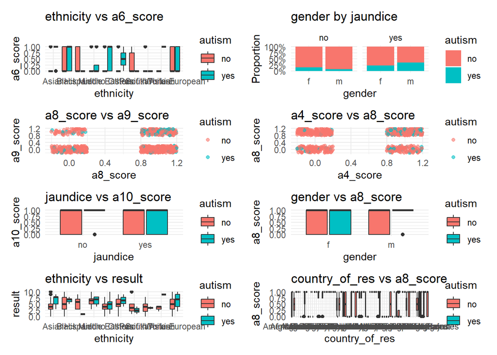

```r
library(ggplot2)
library(dplyr)
library(patchwork)

# Your significant interactions
interactions <- data.frame(
  var1 = c("a6_score", "gender", "a8_score", "a4_score", "a10_score", "a8_score", "ethnicity", "a8_score"),
  var2 = c("ethnicity", "jaundice", "a9_score", "a8_score", "jaundice", "gender", "result", "country_of_res")
)

# Function to generate interaction plots and return ggplot object
generate_plot <- function(data, var1, var2) {
  v1 <- data[[var1]]
  v2 <- data[[var2]]

  is_v1_cat <- is.factor(v1) || is.character(v1)
  is_v2_cat <- is.factor(v2) || is.character(v2)

  if (!is_v1_cat & !is_v2_cat) {
    return(
      ggplot(data, aes_string(x = var1, y = var2, color = "autism")) +
        geom_point(alpha = 0.6, position = position_jitter(width = 0.2, height = 0.2)) +
        theme_minimal() +
        labs(title = paste(var1, "vs", var2))
    )
  } else if (is_v1_cat & is_v2_cat) {
    return(
      ggplot(data, aes_string(x = var1, fill = "autism")) +
        geom_bar(position = "fill") +
        facet_wrap(as.formula(paste("~", var2))) +
        scale_y_continuous(labels = scales::percent_format()) +
        theme_minimal() +
        labs(y = "Proportion", title = paste(var1, "by", var2))
    )
  } else {
    if (is_v1_cat) {
      return(
        ggplot(data, aes_string(x = var1, y = var2, fill = "autism")) +
          geom_boxplot() +
          theme_minimal() +
          labs(title = paste(var1, "vs", var2))
      )
    } else {
      return(
        ggplot(data, aes_string(x = var2, y = var1, fill = "autism")) +
          geom_boxplot() +
          theme_minimal() +
          labs(title = paste(var2, "vs", var1))
      )
    }
  }
}

# Generate all plots and store them
plots <- list()
for (i in 1:nrow(interactions)) {
  plots[[i]] <- generate_plot(autism, interactions$var1[i], interactions$var2[i])
}

# Display in grid: 2 columns
wrap_plots(plots, ncol = 2)
```

## Modeling

### Base Logistic Regression Model

**SHOW ME THE CODE!**

```r
library(recipes)
```

**SHOW ME THE CODE!**

```r
library(rsample)
```

**SHOW ME THE CODE!**

```r
library(parsnip)
```

**SHOW ME THE CODE!**

```r
library(workflows)
```

**SHOW ME THE CODE!**

```r
library(tune)
```

**SHOW ME THE CODE!**

```r
library(yardstick)
```

**SHOW ME THE CODE!**

```r
library(broom)
##The outcome is a factor
class(autism$autism)
```

```
[1] "factor"
```

**SHOW ME THE CODE!**

```r
##We will be predicting the P(yes)
levels(autism$autism)
```

```
[1] "no"  "yes"
```

**SHOW ME THE CODE!**

```r
autism_recipe <- recipe(autism ~ a1_score + a2_score + a3_score + a4_score + a5_score + a6_score + a7_score + a8_score + a9_score + a10_score + age + gender + ethnicity + jaundice + country_of_res + relation + class_asd,
                data = autism) %>%
  step_dummy(all_nominal_predictors())

set.seed(123)
autism_kfolds <- vfold_cv(autism, v = 10, repeats = 5, strata = "autism")

autism_logistic <- logistic_reg() %>%
                  set_mode("classification") %>%
                  set_engine("glm")

autism_wf <- workflow() %>%
            add_recipe(autism_recipe) %>%
            add_model(autism_logistic)

set.seed(123)
autism_resammple <- fit_resamples(
              autism_wf,
              resamples = autism_kfolds,
              metrics = metric_set(accuracy, roc_auc, kap, sens, spec, brier_class))
```

```
→ A | warning: prediction from rank-deficient fit; attr(*, "non-estim") has doubtful cases
```

```
There were issues with some computations   A: x1
```

```
→ B | warning: glm.fit: fitted probabilities numerically 0 or 1 occurred
```

[output not shown]

**SHOW ME THE CODE!**

```r
autism_resammple %>% collect_metrics()
```

```
# A tibble: 6 × 6
  .metric     .estimator  mean     n std_err .config
  <chr>       <chr>      <dbl> <int>   <dbl> <chr>
1 accuracy    binary     0.846    50 0.00404 Preprocessor1_Model1
2 brier_class binary     0.124    50 0.00275 Preprocessor1_Model1
3 kap         binary     0.116    50 0.0170  Preprocessor1_Model1
4 roc_auc     binary     0.620    50 0.0141  Preprocessor1_Model1
5 sens        binary     0.951    50 0.00425 Preprocessor1_Model1
6 spec        binary     0.139    50 0.0127  Preprocessor1_Model1
```

**SHOW ME THE CODE!**

```r
##Extract coefficients (after fitting on full data)
autism_model <- autism_wf %>%
  fit(autism) %>%
  extract_fit_parsnip() %>%
  tidy()

autism_model
```

```
# A tibble: 94 × 5
   term        estimate std.error statistic p.value
   <chr>          <dbl>     <dbl>     <dbl>   <dbl>
 1 (Intercept)  -2.86       1.77     -1.61   0.107
 2 a1_score      0.642      0.407     1.58   0.115
 3 a2_score     -0.369      0.315    -1.17   0.242
 4 a3_score     -0.0571     0.343    -0.167  0.868
 5 a4_score      0.609      0.357     1.71   0.0879
 6 a5_score      0.120      0.364     0.331  0.741
 7 a6_score     -0.249      0.404    -0.616  0.538
 8 a7_score     -0.508      0.308    -1.65   0.0993
 9 a8_score      0.129      0.312     0.412  0.680
10 a9_score      0.761      0.390     1.95   0.0514
# ℹ 84 more rows
```

### Custom Model 1

**SHOW ME THE CODE!**

```r
library(themis) # for upsample
```

**SHOW ME THE CODE!**

```r
autism_recipe2 <- recipe(autism ~ a1_score + a2_score + a3_score + a4_score + a5_score + a6_score + a7_score + a8_score + a9_score + a10_score + age + gender + ethnicity + jaundice + country_of_res + relation + class_asd + result,
                data = autism) %>%
  step_interact(terms = ~ ethnicity:result) %>%
  step_interact(terms = ~ gender:jaundice) %>%
  step_dummy(all_nominal_predictors()) %>%
  step_upsample(autism, over_ratio = 1)

set.seed(123)
autism_kfolds <- vfold_cv(autism, v = 10, repeats = 5, strata = "autism")

autism_logistic <- logistic_reg() %>%
                  set_mode("classification") %>%
                  set_engine("glm")

autism_wf2 <- workflow() %>%
            add_recipe(autism_recipe2) %>%
            add_model(autism_logistic)

set.seed(123)
autism_resammple2 <- fit_resamples(
              autism_wf2,
              resamples = autism_kfolds,
              metrics = metric_set(accuracy, roc_auc, kap, sens, spec, brier_class))
```

```
→ A | warning: glm.fit: fitted probabilities numerically 0 or 1 occurred
```

```
There were issues with some computations   A: x1
```

```
→ B | warning: prediction from rank-deficient fit; attr(*, "non-estim") has doubtful cases
```

[output not shown]

**SHOW ME THE CODE!**

```r
autism_resammple2 %>% collect_metrics()
```

```
# A tibble: 6 × 6
  .metric     .estimator  mean     n std_err .config
  <chr>       <chr>      <dbl> <int>   <dbl> <chr>
1 accuracy    binary     0.696    50 0.00739 Preprocessor1_Model1
2 brier_class binary     0.219    50 0.00503 Preprocessor1_Model1
3 kap         binary     0.156    50 0.0138  Preprocessor1_Model1
4 roc_auc     binary     0.608    50 0.0132  Preprocessor1_Model1
5 sens        binary     0.721    50 0.00826 Preprocessor1_Model1
6 spec        binary     0.528    50 0.0218  Preprocessor1_Model1
```

**SHOW ME THE CODE!**

```r
##Extract coefficients (after fitting on full data)
autism_model2 <- autism_wf2 %>%
  fit(autism) %>%
  extract_fit_parsnip() %>%
  tidy()
```

**SHOW ME THE CODE!**

```r
autism_model2
```

```
# A tibble: 105 × 5
   term        estimate std.error statistic  p.value
   <chr>          <dbl>     <dbl>     <dbl>    <dbl>
 1 (Intercept)   -2.51      1.64     -1.53  0.126
 2 a1_score       0.816     0.259     3.15  0.00161
 3 a2_score      -0.341     0.224    -1.52  0.128
 4 a3_score       0.483     0.226     2.14  0.0321
 5 a4_score       0.779     0.230     3.39  0.000706
 6 a5_score       0.294     0.235     1.25  0.211
 7 a6_score       0.136     0.262     0.517 0.605
 8 a7_score      -0.474     0.220    -2.15  0.0312
 9 a8_score       0.377     0.229     1.65  0.0988
10 a9_score       0.690     0.260     2.65  0.00797
# ℹ 95 more rows
```

Adds upsampling and interaction terms

### Custom Model 2

Adds elastic net

**SHOW ME THE CODE!**

```r
library(themis) # for upsample
library(dials)
```

**SHOW ME THE CODE!**

```r
# Define recipe with interactions and upsampling
autism_recipe3 <- recipe(autism ~ a1_score + a2_score + a3_score + a4_score + a5_score + a6_score + a7_score + a8_score + a9_score + a10_score + age + gender + ethnicity + jaundice + country_of_res + relation + class_asd + result,
                data = autism) %>%
  step_interact(terms = ~ ethnicity:result + gender:jaundice) %>%
  step_dummy(all_nominal_predictors()) %>%
  step_upsample(autism, over_ratio = 1)

# Cross-validation setup
set.seed(123)
autism_kfolds <- vfold_cv(autism, v = 10, repeats = 5, strata = "autism")

# Define penalized logistic regression model with tunable hyperparameters
autism_en_model <- logistic_reg(penalty = tune(), mixture = tune()) %>%
  set_mode("classification") %>%
  set_engine("glmnet")

# Define workflow
autism_en_wflow <- workflow() %>%
  add_recipe(autism_recipe3) %>%
  add_model(autism_en_model)

# Create tuning grid (space-filling design)
en_param <- extract_parameter_set_dials(autism_en_model)
glh_en <- grid_space_filling(en_param, size = 10, type = "latin_hypercube")

# Tune the model with resampling
set.seed(123)
autism_en_tune <- tune_grid(
  autism_en_wflow,
  resamples = autism_kfolds,
  grid = glh_en,
  metrics = metric_set(accuracy, roc_auc, kap, sens, spec, brier_class)
)
```

**SHOW ME THE CODE!**

```r
# Collect and print metrics from tuning
autism_en_tune %>% collect_metrics()
```

```
# A tibble: 60 × 8
        penalty mixture .metric     .estimator  mean     n std_err .config
          <dbl>   <dbl> <chr>       <chr>      <dbl> <int>   <dbl> <chr>
 1 0.0000000700  0.0751 accuracy    binary     0.696    50 0.00701 Preprocessor…
 2 0.0000000700  0.0751 brier_class binary     0.218    50 0.00476 Preprocessor…
 3 0.0000000700  0.0751 kap         binary     0.153    50 0.0127  Preprocessor…
 4 0.0000000700  0.0751 roc_auc     binary     0.613    50 0.0122  Preprocessor…
 5 0.0000000700  0.0751 sens        binary     0.722    50 0.00808 Preprocessor…
 6 0.0000000700  0.0751 spec        binary     0.521    50 0.0208  Preprocessor…
 7 0.00205       0.224  accuracy    binary     0.700    50 0.00739 Preprocessor…
 8 0.00205       0.224  brier_class binary     0.208    50 0.00450 Preprocessor…
 9 0.00205       0.224  kap         binary     0.165    50 0.0126  Preprocessor…
10 0.00205       0.224  roc_auc     binary     0.642    50 0.0120  Preprocessor…
# ℹ 50 more rows
```

**SHOW ME THE CODE!**

```r
# Select best parameters based on ROC AUC
autism_en_param <- autism_en_tune %>% select_best(metric = "roc_auc")

# Finalize the model with best parameters
autism_en_model2 <- finalize_model(autism_en_model, autism_en_param)

# Update the workflow with the finalized model
autism_en_wflow2 <- autism_en_wflow %>%
  update_model(autism_en_model2)

# Fit on resamples to evaluate metrics
autism_resample_final <- fit_resamples(
  autism_en_wflow2,
  resamples = autism_kfolds,
  metrics = metric_set(accuracy, roc_auc, kap, sens, spec, brier_class)
)

# Collect metrics after using the best parameters
autism_resample_final %>%
  collect_metrics()
```

```
# A tibble: 6 × 6
  .metric     .estimator  mean     n std_err .config
  <chr>       <chr>      <dbl> <int>   <dbl> <chr>
1 accuracy    binary     0.683    50 0.00803 Preprocessor1_Model1
2 brier_class binary     0.201    50 0.00255 Preprocessor1_Model1
3 kap         binary     0.183    50 0.0146  Preprocessor1_Model1
4 roc_auc     binary     0.711    50 0.0127  Preprocessor1_Model1
5 sens        binary     0.692    50 0.00941 Preprocessor1_Model1
6 spec        binary     0.625    50 0.0267  Preprocessor1_Model1
```

**SHOW ME THE CODE!**

```r
# Fit the finalized workflow to the full data
autism_en_final_fit <- autism_en_wflow2 %>%
  fit(data = autism)

# Collect and tidy the coefficients
autism_en_params <- autism_en_final_fit %>%
  extract_fit_parsnip() %>%
  tidy()

# Print the coefficients
autism_en_params
```

```
# A tibble: 105 × 3
   term        estimate penalty
   <chr>          <dbl>   <dbl>
 1 (Intercept)   -1.30   0.0387
 2 a1_score       0.267  0.0387
 3 a2_score       0      0.0387
 4 a3_score       0      0.0387
 5 a4_score       0.658  0.0387
 6 a5_score       0      0.0387
 7 a6_score       0      0.0387
 8 a7_score      -0.156  0.0387
 9 a8_score       0      0.0387
10 a9_score       0.102  0.0387
# ℹ 95 more rows
```

**SHOW ME THE CODE!**

```r
library(dplyr)

# Filter out predictors with zero coefficients
autism_en_params_nonzero <- autism_en_params %>%
  filter(estimate != 0)

# Print the filtered results
autism_en_params_nonzero
```

```
# A tibble: 24 × 3
   term                              estimate penalty
   <chr>                                <dbl>   <dbl>
 1 (Intercept)                      -1.30      0.0387
 2 a1_score                          0.267     0.0387
 3 a4_score                          0.658     0.0387
 4 a7_score                         -0.156     0.0387
 5 a9_score                          0.102     0.0387
 6 a10_score                         0.0262    0.0387
 7 age                               0.0273    0.0387
 8 ethnicityHispanic_x_result       -0.0498    0.0387
 9 ethnicityOthers_x_result         -0.000175  0.0387
10 ethnicityWhite-European_x_result  0.0146    0.0387
# ℹ 14 more rows
```

### Elastic Net

**SHOW ME THE CODE!**

```r
library(themis) # for upsample

# Define recipe with interactions and upsampling
autism_recipe4 <- recipe(autism ~ a1_score + a2_score + a3_score + a4_score + a5_score + a6_score + a7_score + a8_score + a9_score + a10_score + age + gender + ethnicity + jaundice + country_of_res + relation + class_asd,
                data = autism) %>%
  step_dummy(all_nominal_predictors()) %>%
  step_upsample(autism, over_ratio = 1)

# Cross-validation setup
set.seed(123)
autism_kfolds <- vfold_cv(autism, v = 10, repeats = 5, strata = "autism")

# Define penalized logistic regression model with tunable hyperparameters
autism_en_model <- logistic_reg(penalty = tune(), mixture = tune()) %>%
  set_mode("classification") %>%
  set_engine("glmnet")

# Define workflow
autism_en_wflow3 <- workflow() %>%
  add_recipe(autism_recipe4) %>%
  add_model(autism_en_model)

# Create tuning grid (space-filling design)
en_param <- extract_parameter_set_dials(autism_en_model)
glh_en <- grid_space_filling(en_param, size = 10, type = "latin_hypercube")

# Tune the model with resampling
set.seed(123)
autism_en_tune <- tune_grid(
  autism_en_wflow3,
  resamples = autism_kfolds,
  grid = glh_en,
  metrics = metric_set(accuracy, roc_auc, kap, sens, spec, brier_class)
)

# Collect and print metrics from tuning
autism_en_tune %>% collect_metrics()
```

```
# A tibble: 60 × 8
        penalty mixture .metric     .estimator  mean     n std_err .config
          <dbl>   <dbl> <chr>       <chr>      <dbl> <int>   <dbl> <chr>
 1 0.0000000700  0.0751 accuracy    binary     0.682    50 0.00840 Preprocessor…
 2 0.0000000700  0.0751 brier_class binary     0.222    50 0.00517 Preprocessor…
 3 0.0000000700  0.0751 kap         binary     0.149    50 0.0142  Preprocessor…
 4 0.0000000700  0.0751 roc_auc     binary     0.616    50 0.0142  Preprocessor…
 5 0.0000000700  0.0751 sens        binary     0.703    50 0.00936 Preprocessor…
 6 0.0000000700  0.0751 spec        binary     0.539    50 0.0216  Preprocessor…
 7 0.00205       0.224  accuracy    binary     0.686    50 0.00815 Preprocessor…
 8 0.00205       0.224  brier_class binary     0.214    50 0.00490 Preprocessor…
 9 0.00205       0.224  kap         binary     0.156    50 0.0141  Preprocessor…
10 0.00205       0.224  roc_auc     binary     0.638    50 0.0135  Preprocessor…
# ℹ 50 more rows
```

**SHOW ME THE CODE!**

```r
# Select best parameters based on ROC AUC
autism_en_param3 <- autism_en_tune %>% select_best(metric = "roc_auc")

# Finalize the model with best parameters
autism_en_model3 <- finalize_model(autism_en_model, autism_en_param3)

# Update the workflow with the finalized model
autism_en_wflow4 <- autism_en_wflow3 %>%
  update_model(autism_en_model3)

# Fit on resamples to evaluate metrics
autism_resample_final3 <- fit_resamples(
  autism_en_wflow4,
  resamples = autism_kfolds,
  metrics = metric_set(accuracy, roc_auc, kap, sens, spec, brier_class)
)

# Collect metrics after using the best parameters
autism_resample_final3 %>%
  collect_metrics()
```

```
# A tibble: 6 × 6
  .metric     .estimator  mean     n std_err .config
  <chr>       <chr>      <dbl> <int>   <dbl> <chr>
1 accuracy    binary     0.685    50 0.00836 Preprocessor1_Model1
2 brier_class binary     0.203    50 0.00254 Preprocessor1_Model1
3 kap         binary     0.190    50 0.0155  Preprocessor1_Model1
4 roc_auc     binary     0.709    50 0.0129  Preprocessor1_Model1
5 sens        binary     0.693    50 0.00954 Preprocessor1_Model1
6 spec        binary     0.634    50 0.0266  Preprocessor1_Model1
```

**SHOW ME THE CODE!**

```r
# Fit the finalized workflow to the full data
autism_en_final_fit3 <- autism_en_wflow4 %>%
  fit(data = autism)

# Collect and tidy the coefficients
autism_en_params3 <- autism_en_final_fit3 %>%
  extract_fit_parsnip() %>%
  tidy()

# Print the coefficients
autism_en_params3
```

```
# A tibble: 94 × 3
   term        estimate penalty
   <chr>          <dbl>   <dbl>
 1 (Intercept)  -1.44    0.0387
 2 a1_score      0.192   0.0387
 3 a2_score      0       0.0387
 4 a3_score      0       0.0387
 5 a4_score      0.611   0.0387
 6 a5_score      0       0.0387
 7 a6_score      0       0.0387
 8 a7_score     -0.0219  0.0387
 9 a8_score      0       0.0387
10 a9_score      0.233   0.0387
# ℹ 84 more rows
```

**SHOW ME THE CODE!**

```r
library(dplyr)

# Filter out predictors with zero coefficients
autism_en_params_nonzero3 <- autism_en_params3 %>%
  filter(estimate != 0)

# Print the filtered results
autism_en_params_nonzero3
```

```
# A tibble: 23 × 3
   term                     estimate penalty
   <chr>                       <dbl>   <dbl>
 1 (Intercept)               -1.44    0.0387
 2 a1_score                   0.192   0.0387
 3 a4_score                   0.611   0.0387
 4 a7_score                  -0.0219  0.0387
 5 a9_score                   0.233   0.0387
 6 a10_score                  0.259   0.0387
 7 age                        0.0237  0.0387
 8 gender_m                  -0.106   0.0387
 9 ethnicity_Latino           0.0824  0.0387
10 ethnicity_White.European   0.0622  0.0387
# ℹ 13 more rows
```

No interaction terms

## Additional Code for Report Graphics

**SHOW ME THE CODE!**

```r
library(gt)
```

**SHOW ME THE CODE!**

```r
# Add a column to identify each model
autism_metrics <- autism_resammple %>% collect_metrics() %>% mutate(Model = "Base Model")
autism_metrics2 <- autism_resammple2 %>% collect_metrics() %>% mutate(Model = "Custom Model 1")
autism_metrics3 <- autism_resample_final %>% collect_metrics() %>% mutate(Model = "Custom Model 2")
autism_metrics4 <- autism_resample_final3 %>% collect_metrics() %>% mutate(Model = "EN Model")

# Combine all into one data frame
all_metrics <- bind_rows(autism_metrics, autism_metrics2, autism_metrics3, autism_metrics4)

# Pivot wider to compare metrics across models
metrics_wide <- all_metrics %>%
  select(Model, .metric, mean) %>%
  pivot_wider(names_from = .metric, values_from = mean)

# Print the final comparison table using gt
metrics_wide %>%
  gt() %>%
  tab_header(
    title = "Model Comparison: Performance Metrics",
    subtitle = "Evaluating classification models on Autism Screening"
  ) %>%
  fmt_number(
    columns = where(is.numeric),
    decimals = 3
  ) %>%
  cols_label(
    Model = "Model",
    accuracy = "Accuracy",
    kap = "Kappa",
    roc_auc = "ROC AUC",
    sens = "Specificity",
    spec = "Sensitivity",
    brier_class = "Brier Score"
  ) %>%
  tab_style(
    style = list(
      cell_text(weight = "bold")
    ),
    locations = cells_column_labels(everything())
  ) %>%
  opt_table_outline() %>%
  opt_row_striping()
```

Model Comparison: Performance Metrics

Evaluating classification models on Autism Screening

[output not shown]

### Base Model

**SHOW ME THE CODE!**

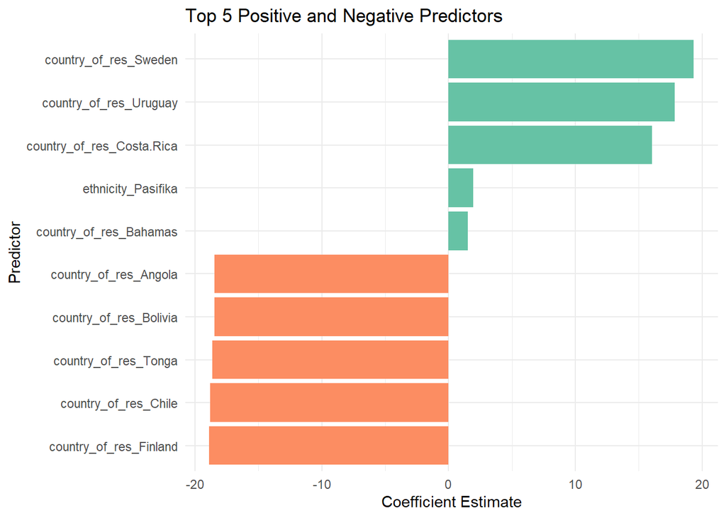

```r
library(dplyr)
library(ggplot2)


# Get top 5 positive and top 5 negative predictors
top_positivea <- autism_model %>%
  arrange(desc(estimate)) %>%
  slice_head(n = 5)

top_negativea <- autism_model %>%
  arrange(estimate) %>%
  slice_head(n = 5)

# Combine and plot
top_combineda <- bind_rows(top_positivea, top_negativea)

ggplot(top_combineda, aes(x = reorder(term, estimate), y = estimate, fill = estimate > 0)) +
  geom_col(show.legend = FALSE) +
  coord_flip() +
  labs(
    title = "Top 5 Positive and Negative Predictors",
    x = "Predictor",
    y = "Coefficient Estimate"
  ) +
  scale_fill_manual(values = c("TRUE" = "#66c2a5", "FALSE" = "#fc8d62")) +
  theme_minimal()
```

**SHOW ME THE CODE!**

```r
library(dplyr)

# Count and list positive and negative predictors
positive_predictorsa <- autism_model %>%
  filter(term != "(Intercept)", estimate > 0) %>%
  arrange(desc(estimate))

negative_predictorsa <- autism_model %>%
  filter(term != "(Intercept)", estimate < 0) %>%
  arrange(estimate)

# Print counts
cat("Number of positive predictors:", nrow(positive_predictorsa), "\n")
```

```
Number of positive predictors: 27
```

**SHOW ME THE CODE!**

```r
cat("Number of negative predictors:", nrow(negative_predictorsa), "\n\n")
```

```
Number of negative predictors: 66
```

**SHOW ME THE CODE!**

```r
# List predictors
cat("Positive predictors:\n")
```

```
Positive predictors:
```

**SHOW ME THE CODE!**

```r
print(positive_predictorsa)
```

```
# A tibble: 27 × 5
   term                      estimate std.error statistic p.value
   <chr>                        <dbl>     <dbl>     <dbl>   <dbl>
 1 country_of_res_Sweden       19.3    4379.      0.00442  0.996
 2 country_of_res_Uruguay      17.8    6523.      0.00273  0.998
 3 country_of_res_Costa.Rica   16.0    6523.      0.00246  0.998
 4 ethnicity_Pasifika           1.96      1.16    1.69     0.0918
 5 country_of_res_Bahamas       1.53      1.78    0.855    0.392
 6 ethnicity_Latino             1.32      1.30    1.02     0.310
 7 country_of_res_Belgium       0.951     1.77    0.537    0.591
 8 ethnicity_Turkish            0.903     1.52    0.595    0.552
 9 country_of_res_Brazil        0.887     1.38    0.642    0.521
10 jaundice_yes                 0.884     0.375   2.36     0.0185
# ℹ 17 more rows
```

**SHOW ME THE CODE!**

```r
cat("\nNegative predictors:\n")
```

```
Negative predictors:
```

**SHOW ME THE CODE!**

```r
print(negative_predictorsa)
```

```
# A tibble: 66 × 5
   term                          estimate std.error statistic p.value
   <chr>                            <dbl>     <dbl>     <dbl>   <dbl>
 1 country_of_res_Finland           -18.9     6523.  -0.00289   0.998
 2 country_of_res_Chile             -18.8     6523.  -0.00288   0.998
 3 country_of_res_Tonga             -18.6     6523.  -0.00286   0.998
 4 country_of_res_Bolivia           -18.5     6523.  -0.00283   0.998
 5 country_of_res_Angola            -18.5     6523.  -0.00283   0.998
 6 country_of_res_Cyprus            -18.3     6523.  -0.00281   0.998
 7 country_of_res_Pakistan          -18.3     3525.  -0.00518   0.996
 8 country_of_res_Oman              -18.3     6523.  -0.00280   0.998
 9 country_of_res_Czech.Republic    -18.3     6523.  -0.00280   0.998
10 country_of_res_China             -18.2     6523.  -0.00279   0.998
# ℹ 56 more rows
```

### Custom Model 1

**SHOW ME THE CODE!**

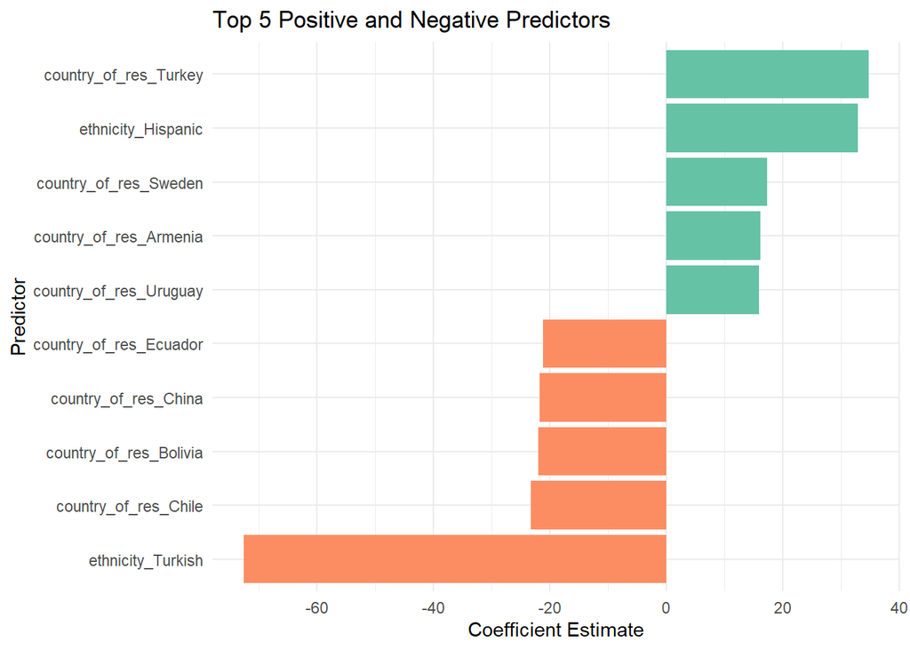

```r
library(dplyr)
library(ggplot2)


# Get top 5 positive and top 5 negative predictors
top_positiveb <- autism_model2 %>%
  arrange(desc(estimate)) %>%
  slice_head(n = 5)

top_negativeb <- autism_model2 %>%
  arrange(estimate) %>%
  slice_head(n = 5)

# Combine and plot
top_combinedb <- bind_rows(top_positiveb, top_negativeb)

ggplot(top_combinedb, aes(x = reorder(term, estimate), y = estimate, fill = estimate > 0)) +
  geom_col(show.legend = FALSE) +
  coord_flip() +
  labs(
    title = "Top 5 Positive and Negative Predictors",
    x = "Predictor",
    y = "Coefficient Estimate"
  ) +
  scale_fill_manual(values = c("TRUE" = "#66c2a5", "FALSE" = "#fc8d62")) +
  theme_minimal()
```

**SHOW ME THE CODE!**

```r
library(dplyr)

#Count and list positive and negative predictors
positive_predictorsb <- autism_model2 %>%
  filter(term != "(Intercept)", estimate > 0) %>%
  arrange(desc(estimate))

negative_predictorsb <- autism_model2 %>%
  filter(term != "(Intercept)", estimate < 0) %>%
  arrange(estimate)

#Print counts
cat("Number of positive predictors:", nrow(positive_predictorsb), "\n")
```

```
Number of positive predictors: 34
```

**SHOW ME THE CODE!**

```r
cat("Number of negative predictors:", nrow(negative_predictorsb), "\n\n")
```

```
Number of negative predictors: 69
```

**SHOW ME THE CODE!**

```r
# List predictors
cat("Positive predictors:\n")
```

```
Positive predictors:
```

**SHOW ME THE CODE!**

```r
print(positive_predictorsb)
```

```
# A tibble: 34 × 5
   term                      estimate std.error statistic p.value
   <chr>                        <dbl>     <dbl>     <dbl>   <dbl>
 1 country_of_res_Turkey        34.7    7843.     0.00443 0.996
 2 ethnicity_Hispanic           32.9    1454.     0.0226  0.982
 3 country_of_res_Sweden        17.3    1434.     0.0121  0.990
 4 country_of_res_Armenia       16.2    1872.     0.00863 0.993
 5 country_of_res_Uruguay       15.9    2917.     0.00545 0.996
 6 country_of_res_Costa.Rica    12.8    2063.     0.00618 0.995
 7 ethnicityTurkish_x_result     9.89    864.     0.0115  0.991
 8 ethnicity_Latino              5.86      2.68   2.18    0.0290
 9 ethnicity_Pasifika            4.06      1.37   2.96    0.00306
10 relation_Parent               1.82      1.47   1.24    0.215
# ℹ 24 more rows
```

**SHOW ME THE CODE!**

```r
cat("\nNegative predictors:\n")
```

```
Negative predictors:
```

**SHOW ME THE CODE!**

```r
print(negative_predictorsb)
```

```
# A tibble: 69 × 5
   term                        estimate std.error statistic p.value
   <chr>                          <dbl>     <dbl>     <dbl>   <dbl>
 1 ethnicity_Turkish              -72.6     5918.  -0.0123    0.990
 2 country_of_res_Chile           -23.2     6523.  -0.00356   0.997
 3 country_of_res_Bolivia         -22.0     6523.  -0.00337   0.997
 4 country_of_res_China           -21.7     6523.  -0.00332   0.997
 5 country_of_res_Ecuador         -21.2     6523.  -0.00324   0.997
 6 country_of_res_Oman            -21.1     6523.  -0.00324   0.997
 7 country_of_res_Angola          -21.0     6523.  -0.00321   0.997
 8 country_of_res_Sierra.Leone    -20.8     6523.  -0.00319   0.997
 9 country_of_res_Finland         -20.7     6523.  -0.00317   0.997
10 country_of_res_Tonga           -20.3     6523.  -0.00311   0.998
# ℹ 59 more rows
```

### Custom Model 2

**SHOW ME THE CODE!**

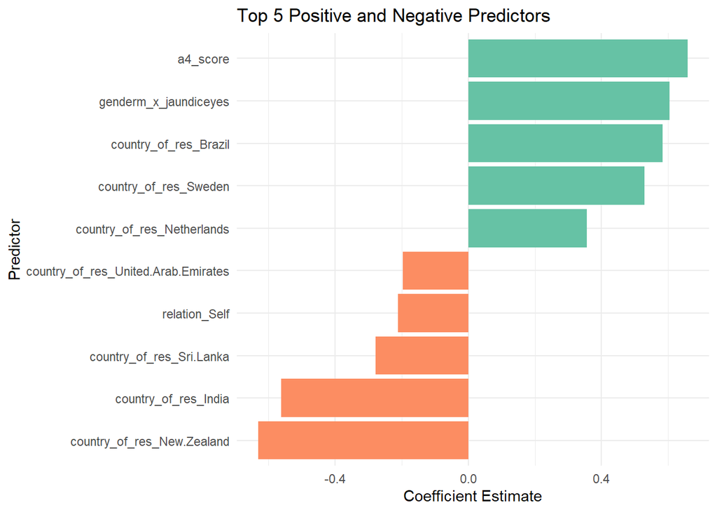

```r
library(dplyr)
library(ggplot2)


# Get top 5 positive and top 5 negative predictors
top_positivec <- autism_en_params_nonzero %>%
  arrange(desc(estimate)) %>%
  slice_head(n = 5)

top_negativec <- autism_en_params_nonzero %>%
  filter(term != "(Intercept)") %>%
  arrange(estimate) %>%
  slice_head(n = 5)

# Combine and plot
top_combinedc <- bind_rows(top_positivec, top_negativec)

ggplot(top_combinedc, aes(x = reorder(term, estimate), y = estimate, fill = estimate > 0)) +
  geom_col(show.legend = FALSE) +
  coord_flip() +
  labs(
    title = "Top 5 Positive and Negative Predictors",
    x = "Predictor",
    y = "Coefficient Estimate"
  ) +
  scale_fill_manual(values = c("TRUE" = "#66c2a5", "FALSE" = "#fc8d62")) +
  theme_minimal()
```

**SHOW ME THE CODE!**

```r
library(dplyr)

#Count and list positive and negative predictors
positive_predictorsc <- autism_en_params_nonzero %>%
  filter(term != "(Intercept)", estimate > 0) %>%
  arrange(desc(estimate))

negative_predictorsc <- autism_en_params_nonzero %>%
  filter(term != "(Intercept)", estimate < 0) %>%
  arrange(estimate)

#Print counts
cat("Number of positive predictors:", nrow(positive_predictorsc), "\n")
```

```
Number of positive predictors: 13
```

**SHOW ME THE CODE!**

```r
cat("Number of negative predictors:", nrow(negative_predictorsc), "\n\n")
```

```
Number of negative predictors: 10
```

**SHOW ME THE CODE!**

```r
# List predictors
cat("Positive predictors:\n")
```

```
Positive predictors:
```

**SHOW ME THE CODE!**

```r
print(positive_predictorsc)
```

```
# A tibble: 13 × 3
   term                             estimate penalty
   <chr>                               <dbl>   <dbl>
 1 a4_score                           0.658   0.0387
 2 genderm_x_jaundiceyes              0.605   0.0387
 3 country_of_res_Brazil              0.584   0.0387
 4 country_of_res_Sweden              0.529   0.0387
 5 country_of_res_Netherlands         0.355   0.0387
 6 a1_score                           0.267   0.0387
 7 ethnicity_Latino                   0.224   0.0387
 8 jaundice_yes                       0.123   0.0387
 9 country_of_res_United.States       0.120   0.0387
10 a9_score                           0.102   0.0387
11 age                                0.0273  0.0387
12 a10_score                          0.0262  0.0387
13 ethnicityWhite-European_x_result   0.0146  0.0387
```

**SHOW ME THE CODE!**

```r
cat("\nNegative predictors:\n")
```

```
Negative predictors:
```

**SHOW ME THE CODE!**

```r
print(negative_predictorsc)
```

```
# A tibble: 10 × 3
   term                                 estimate penalty
   <chr>                                   <dbl>   <dbl>
 1 country_of_res_New.Zealand          -0.631     0.0387
 2 country_of_res_India                -0.562     0.0387
 3 country_of_res_Sri.Lanka            -0.279     0.0387
 4 relation_Self                       -0.211     0.0387
 5 country_of_res_United.Arab.Emirates -0.196     0.0387
 6 a7_score                            -0.156     0.0387
 7 gender_m                            -0.104     0.0387
 8 ethnicityHispanic_x_result          -0.0498    0.0387
 9 country_of_res_Jordan               -0.00242   0.0387
10 ethnicityOthers_x_result            -0.000175  0.0387
```

### Elastic Net

**SHOW ME THE CODE!**

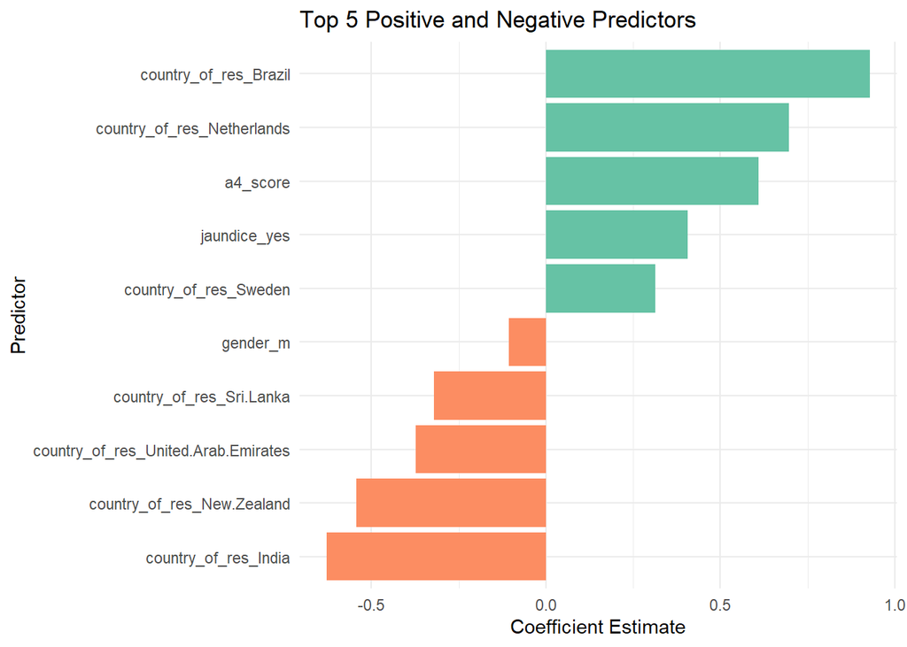

```r
library(dplyr)
library(ggplot2)


# Get top 5 positive and top 5 negative predictors
top_positived <- autism_en_params_nonzero3 %>%
  arrange(desc(estimate)) %>%
  slice_head(n = 5)

top_negatived <- autism_en_params_nonzero3 %>%
  filter(term != "(Intercept)") %>%
  arrange(estimate) %>%
  slice_head(n = 5)

# Combine and plot
top_combinedd <- bind_rows(top_positived, top_negatived)

ggplot(top_combinedd, aes(x = reorder(term, estimate), y = estimate, fill = estimate > 0)) +
  geom_col(show.legend = FALSE) +
  coord_flip() +
  labs(
    title = "Top 5 Positive and Negative Predictors",
    x = "Predictor",
    y = "Coefficient Estimate"
  ) +
  scale_fill_manual(values = c("TRUE" = "#66c2a5", "FALSE" = "#fc8d62")) +
  theme_minimal()
```

**SHOW ME THE CODE!**

```r
library(dplyr)

#Count and list positive and negative predictors
positive_predictorsd <- autism_en_params_nonzero3 %>%
  filter(term != "(Intercept)", estimate > 0) %>%
  arrange(desc(estimate))

negative_predictorsd <- autism_en_params_nonzero3 %>%
  filter(term != "(Intercept)", estimate < 0) %>%
  arrange(estimate)

#Print counts
cat("Number of positive predictors:", nrow(positive_predictorsd), "\n")
```

```
Number of positive predictors: 13
```

**SHOW ME THE CODE!**

```r
cat("Number of negative predictors:", nrow(negative_predictorsd), "\n\n")
```

```
Number of negative predictors: 9
```

**SHOW ME THE CODE!**

```r
# List predictors
cat("Positive predictors:\n")
```

```
Positive predictors:
```

**SHOW ME THE CODE!**

```r
print(positive_predictorsd)
```

```
# A tibble: 13 × 3
   term                          estimate penalty
   <chr>                            <dbl>   <dbl>
 1 country_of_res_Brazil          0.928    0.0387
 2 country_of_res_Netherlands     0.697    0.0387
 3 a4_score                       0.611    0.0387
 4 jaundice_yes                   0.407    0.0387
 5 country_of_res_Sweden          0.314    0.0387
 6 a10_score                      0.259    0.0387
 7 relation_Parent                0.247    0.0387
 8 a9_score                       0.233    0.0387
 9 a1_score                       0.192    0.0387
10 ethnicity_Latino               0.0824   0.0387
11 ethnicity_White.European       0.0622   0.0387
12 age                            0.0237   0.0387
13 country_of_res_United.Kingdom  0.00172  0.0387
```

**SHOW ME THE CODE!**

```r
cat("\nNegative predictors:\n")
```

```
Negative predictors:
```

**SHOW ME THE CODE!**

```r
print(negative_predictorsd)
```

```
# A tibble: 9 × 3
  term                                estimate penalty
  <chr>                                  <dbl>   <dbl>
1 country_of_res_India                 -0.629   0.0387
2 country_of_res_New.Zealand           -0.544   0.0387
3 country_of_res_United.Arab.Emirates  -0.374   0.0387
4 country_of_res_Sri.Lanka             -0.320   0.0387
5 gender_m                             -0.106   0.0387
6 relation_Self                        -0.0924  0.0387
7 country_of_res_Jordan                -0.0770  0.0387
8 a7_score                             -0.0219  0.0387
9 country_of_res_Iran                  -0.0144  0.0387
```